# R_Project_3

## Question 3 (30 points in total)

1. Use three variables (‘GRE.Score’,‘TOEFL.Score’, ‘CGPA’) to build a multiple linear regression model to predict ‘Chance.of.Admit’. Display a summary of your model indicating Residuals, Coefficients, …, etc. What conclusion can you draw from this summary? (8 points)

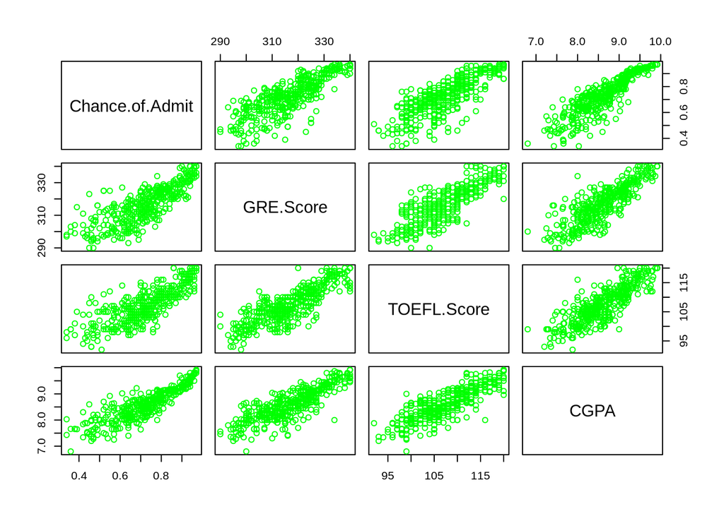

```r
vars <- c("Chance.of.Admit", "GRE.Score", "TOEFL.Score", "CGPA")
pairs(admission[vars],
      col = "green")
```

```r
lm(Chance.of.Admit ~ GRE.Score + TOEFL.Score + CGPA, data = admission)
```

```
##
## Call:
## lm(formula = Chance.of.Admit ~ GRE.Score + TOEFL.Score + CGPA,
##     data = admission)
##
## Coefficients:
## (Intercept)    GRE.Score  TOEFL.Score         CGPA
##   -1.585698     0.002266     0.003112     0.146284
```

```r
summary(lm(Chance.of.Admit ~ GRE.Score + TOEFL.Score + CGPA, data = admission))
```

```
##
## Call:
## lm(formula = Chance.of.Admit ~ GRE.Score + TOEFL.Score + CGPA,
##     data = admission)
##
## Residuals:
##       Min        1Q    Median        3Q       Max
## -0.290375 -0.023030  0.008255  0.040153  0.143108
##
## Coefficients:
##               Estimate Std. Error t value Pr(>|t|)
## (Intercept) -1.5856984  0.1058153 -14.986  < 2e-16 ***
## GRE.Score    0.0022660  0.0005929   3.822 0.000154 ***
## TOEFL.Score  0.0031123  0.0011070   2.812 0.005176 **
## CGPA         0.1462844  0.0111770  13.088  < 2e-16 ***
## ---
## Signif. codes:  0 '***' 0.001 '**' 0.01 '*' 0.05 '.' 0.1 ' ' 1
##
## Residual standard error: 0.06632 on 396 degrees of freedom
## Multiple R-squared:  0.7854, Adjusted R-squared:  0.7837
## F-statistic:   483 on 3 and 396 DF,  p-value: < 2.2e-16
```

```r
#Conclusion:

#Based on the Scatter Plot matrix, all variables (GRE.Score, TOEFL.Score, CGPA) seem to be positively correlated with Chance.of.Admit.

#Based on the summary:

str(admission)
```

```
## 'data.frame':    400 obs. of  9 variables:
##  $ Serial.No.       : int  1 2 3 4 5 6 7 8 9 10 ...
##  $ GRE.Score        : int  337 324 316 322 314 330 321 308 302 323 ...
##  $ TOEFL.Score      : int  118 107 104 110 103 115 109 101 102 108 ...
##  $ University.Rating: int  4 4 3 3 2 5 3 2 1 3 ...
##  $ SOP              : num  4.5 4 3 3.5 2 4.5 3 3 2 3.5 ...
##  $ LOR              : num  4.5 4.5 3.5 2.5 3 3 4 4 1.5 3 ...
##  $ CGPA             : num  9.65 8.87 8 8.67 8.21 9.34 8.2 7.9 8 8.6 ...
##  $ Research         : int  1 1 1 1 0 1 1 0 0 0 ...
##  $ Chance.of.Admit  : num  0.92 0.76 0.72 0.8 0.65 0.9 0.75 0.68 0.5 0.45 ...
```

```r
#Chance.of.Admit is a numerical variable that can be interpreted that the closer the number to 1 the more chance of admit, the closer number to 0 the less chance of admit.

#Slope for GRE.Score = 0.0022660, meaning that for every additional GRE score, the Chance of Admit would be 0.0022660 more.

#Slope for TOEFL.Score = 0.0031123, meaning that for every additional TOEFL score, the Chance of Admit would be 0.0031123 more.

#Slope for CGPA = 0.1462844, meaning that for every additional CGPA, the Chance of Admit would be 0.1462844 more.

#Out of 3 variables, CGPA has the highest slope which makes it the most valuable independent variable for Chance.of.Admit.

#R2 = ~78% meaning that ~78% of the observed variation can be explained by the model inputs.
```

2. Write the regression equation associated with this multiple regression model? (8 points)

```r
lm(Chance.of.Admit ~ GRE.Score + TOEFL.Score + CGPA, data = admission)
```

```
##
## Call:
## lm(formula = Chance.of.Admit ~ GRE.Score + TOEFL.Score + CGPA,
##     data = admission)
##
## Coefficients:
## (Intercept)    GRE.Score  TOEFL.Score         CGPA
##   -1.585698     0.002266     0.003112     0.146284
```

```r
summary(lm(Chance.of.Admit ~ GRE.Score + TOEFL.Score + CGPA, data = admission))
```

```
##
## Call:
## lm(formula = Chance.of.Admit ~ GRE.Score + TOEFL.Score + CGPA,
##     data = admission)
##
## Residuals:
##       Min        1Q    Median        3Q       Max
## -0.290375 -0.023030  0.008255  0.040153  0.143108
##
## Coefficients:
##               Estimate Std. Error t value Pr(>|t|)
## (Intercept) -1.5856984  0.1058153 -14.986  < 2e-16 ***
## GRE.Score    0.0022660  0.0005929   3.822 0.000154 ***
## TOEFL.Score  0.0031123  0.0011070   2.812 0.005176 **
## CGPA         0.1462844  0.0111770  13.088  < 2e-16 ***
## ---
## Signif. codes:  0 '***' 0.001 '**' 0.01 '*' 0.05 '.' 0.1 ' ' 1
##
## Residual standard error: 0.06632 on 396 degrees of freedom
## Multiple R-squared:  0.7854, Adjusted R-squared:  0.7837
## F-statistic:   483 on 3 and 396 DF,  p-value: < 2.2e-16
```

```r
#The basic model for multiple regression analysis is:

# y = b0 + b1*x1 + … + bn*xn + e

#Where:
# y =  Chance.of.Admit
# b0 =  y-intercept = -1.5856984
# b1 = slope = 0.0022660
# b2 = slope = 0.0031123
# b3 = slope = 0.1462844
# x1 = GRE.Score
# x2 = TOEFL.Score
# x3 = CGPA
# e =  model error (a.k.a. how much variation there is in our estimate of y)

# Applicable to the given multiple regression model, the formula would be as follows:

# Chance.of.Admit =  -1.5856984 + 0.0022660 * GRE.Score + 0.0031123 * TOEFL.Score + 0.1462844 * CGPA + e
```

3. Using this model:

i- Find the chance of admit for the 3rd student and 23rd students in the dataset. (4 points)

```r
#Finding the values in a dataset:

admission_3 <- admission[3, "Chance.of.Admit"]
admission_3
```

```
## [1] 0.72
```